# Analyzing the results

Michael Koch

07-03-2022

# Working through the results of the Mini- (/ Pilot-) simulation for the SVNP

Note, I’m working in the Thesis folder for now to avoid merge conflicts and just overall github gezeik.

# Step1: Prepearations

```r
# load packages outside of simulation
library(papaja)
library(patchwork)
#source required functions & parameters
source('~/OneDrive/ms/thesis/R/functions.R')
source('~/OneDrive/ms/thesis/R/parameters.R')
```

```r
# load results
resultsSVNP <- read.csv("~/OneDrive/ms/thesis/output/resultsSVNP.csv",
                        sep = " ",
                        header = TRUE)
convSVNP <- read.csv("~/OneDrive/ms/thesis/output/convSVNP.csv",
                     sep = " ",
                     header = TRUE)
```

```r
# inspect a bit
nrow(resultsSVNP)
```

```
## [1] 2400
```

```r
range(resultsSVNP$pos)
```

```
## [1]    1 2400
```

```r
length(resultsSVNP$pos) == length(unique(resultsSVNP$pos))
```

```
## [1] TRUE
```

# Post-process

Arrange the data based on conditions and iteration, change the biases of the cross-loadings (wrongly computed for some reason), and add a sigma squared column, and a condition identifier.

```r
resultsSVNP <-
  resultsSVNP %>%
  arrange(sigma, N, cross, iteration) %>%
  mutate(sigmaSqu = sigma^2,
         biasCrossMean_1 = abs(crossEstMean_1 - cross),
         biasCrossMean_2 = abs(crossEstMean_2 - cross),
         biasCrossMean_3 = abs(crossEstMean_3 - cross),
         biasCrossMean_4 = abs(crossEstMean_4 - cross),
         biasCrossMean_5 = abs(crossEstMean_5 - cross),
         biasCrossMean_6 = abs(crossEstMean_6 - cross),
         condID = rep(1:(nrow(condPop)*nrow(condSVNP)), each = nIter)
)
```

## Convergence

Let’s explore the convergence a bit

### Divergent transitions

Not a single divergent transition

```r
totalSumDiv <- sum(convSVNP$sumDiv)
totalSumDiv
```

```
## [1] 0
```

### Effective Sample Size

```r
nIter
```

```
## [1] 200
```

```r
convSVNP %>%
  filter(parameter == "n_eff") %>%
  select(lambdaMainC.1.:theta.6.)%>%
  map_df(function(x){x/samplePars$nSampling}) %>%
  map_df(function(x){x> 0.50}) %>%
  map_df(sum) %>%
  map_df(function(x){ x/ 2400})
```

```
## # A tibble: 1 × 19
##   lambdaMainC.1. lambdaMainC.2. lambdaMainC.3. lambdaMainC.4. lambdaMainC.5.
##            <dbl>          <dbl>          <dbl>          <dbl>          <dbl>
## 1          0.999          0.998              1           1.00           1.00
## # … with 14 more variables: lambdaMainC.6. <dbl>, lambdaCrossC.1. <dbl>,
## #   lambdaCrossC.2. <dbl>, lambdaCrossC.3. <dbl>, lambdaCrossC.4. <dbl>,
## #   lambdaCrossC.5. <dbl>, lambdaCrossC.6. <dbl>, PsiC.1.2. <dbl>,
## #   theta.1. <dbl>, theta.2. <dbl>, theta.3. <dbl>, theta.4. <dbl>,
## #   theta.5. <dbl>, theta.6. <dbl>
```

### R-Hat

```r
convSVNP %>%
  filter(parameter == "Rhat") %>%
  map_df(max) %>%
  map_df(function(x){x < 1.05}) %>%
  select(lambdaMainC.1.:theta.6.)
```

```
## # A tibble: 1 × 19
##   lambdaMainC.1. lambdaMainC.2. lambdaMainC.3. lambdaMainC.4. lambdaMainC.5.
##   <lgl>          <lgl>          <lgl>          <lgl>          <lgl>
## 1 TRUE           TRUE           TRUE           TRUE           TRUE
## # … with 14 more variables: lambdaMainC.6. <lgl>, lambdaCrossC.1. <lgl>,
## #   lambdaCrossC.2. <lgl>, lambdaCrossC.3. <lgl>, lambdaCrossC.4. <lgl>,
## #   lambdaCrossC.5. <lgl>, lambdaCrossC.6. <lgl>, PsiC.1.2. <lgl>,
## #   theta.1. <lgl>, theta.2. <lgl>, theta.3. <lgl>, theta.4. <lgl>,
## #   theta.5. <lgl>, theta.6. <lgl>
```

### Max Treedepth

```r
convSVNP %>%
  filter(parameter == "Rhat") %>%
  select(maxTree) %>%
  map_df(max)
```

```
## # A tibble: 1 × 1
##   maxTree
##     <int>
## 1       8
```

FF met Sara bespreken, maar dit is meer over efficientie dan validiteit van de output, dus het zit sws wel goed!

## Compute Relative Bias

```r
relBiasSVNP <-
 resultsSVNP %>%
  select(mainEstMean_1:mainEstMean_6,
        crossEstMean_1:crossEstMean_6,
        thetaEstMean_1:thetaEstMean_6,
        factCorrEstMean,
        cross,
        sigma,
        sigmaSqu,
        N,
        pos,
        iteration,
        condID) %>%
    mutate(absBiasEstMean_1 = abs(mainEstMean_1-modelPars$main),
           absBiasEstMean_2 = abs(mainEstMean_2-modelPars$main),
           absBiasEstMean_3 = abs(mainEstMean_3-modelPars$main),
           absBiasEstMean_4 = abs(mainEstMean_4-modelPars$main),
           absBiasEstMean_5 = abs(mainEstMean_5-modelPars$main),
           absBiasEstMean_6 = abs(mainEstMean_6-modelPars$main),
           absBiasEstCross_1 = abs(crossEstMean_1-cross),
           absBiasEstCross_2 = abs(crossEstMean_2-cross),
           absBiasEstCross_3 = abs(crossEstMean_3-cross),
           absBiasEstCross_4 = abs(crossEstMean_4-cross),
           absBiasEstCross_5 = abs(crossEstMean_5-cross),
           absBiasEstCross_6 = abs(crossEstMean_6-cross),
           absBiasFactCorrEstMean = abs(factCorrEstMean-modelPars$Psi[1, 2])) %>%
    group_by(as.factor(condID)) %>%
      summarise(
        relEstMean_1 =      mean(absBiasEstMean_1) /modelPars$main[1],
        relBiasEstMean_2 =  mean(absBiasEstMean_2) /modelPars$main[1],
        relBiasEstMean_3 =  mean(absBiasEstMean_3) /modelPars$main[1],
        relBiasEstMean_4 =  mean(absBiasEstMean_4) /modelPars$main[1],
        relBiasEstMean_5 =  mean(absBiasEstMean_5) /modelPars$main[1],
        relBiasEstMean_6 =  mean(absBiasEstMean_6) /modelPars$main[1],
        relBiasEstCross_1 = mean(mean(absBiasEstCross_1)/cross),
        relBiasEstCross_2 = mean(mean(absBiasEstCross_2)/cross),
        relBiasEstCross_3 = mean(mean(absBiasEstCross_3)/cross), # dodgy fix, double check!
        relBiasEstCross_4 = mean(mean(absBiasEstCross_4)/cross),
        relBiasEstCross_5 = mean(mean(absBiasEstCross_5)/cross),
        relBiasEstCross_6 = mean(mean(absBiasEstCross_6)/cross),
        relBiasFactCorrEstMean = mean(absBiasFactCorrEstMean)/modelPars$Psi[1, 2],
        N = mean(N),
        cross = mean(cross),
        sigmaSqu = mean(sigmaSqu)
      )
relBiasSVNP
```

```
## # A tibble: 12 × 17
##    `as.factor(condID)` relEstMean_1 relBiasEstMean_2 relBiasEstMean_3
##    <fct>                      <dbl>            <dbl>            <dbl>
##  1 1                         0.0959           0.0926            0.193
##  2 2                         0.113            0.104             0.540
##  3 3                         0.0610           0.0619            0.175
##  4 4                         0.0813           0.0889            0.518
##  5 5                         0.104            0.101             0.138
##  6 6                         0.103            0.0953            0.322
##  7 7                         0.0696           0.0742            0.110
##  8 8                         0.0869           0.0767            0.176
##  9 9                         0.143            0.148             0.135
## 10 10                        0.180            0.177             0.142
## 11 11                        0.120            0.124             0.114
## 12 12                        0.175            0.156             0.107
## # … with 13 more variables: relBiasEstMean_4 <dbl>, relBiasEstMean_5 <dbl>,
## #   relBiasEstMean_6 <dbl>, relBiasEstCross_1 <dbl>, relBiasEstCross_2 <dbl>,
## #   relBiasEstCross_3 <dbl>, relBiasEstCross_4 <dbl>, relBiasEstCross_5 <dbl>,
## #   relBiasEstCross_6 <dbl>, relBiasFactCorrEstMean <dbl>, N <dbl>,
## #   cross <dbl>, sigmaSqu <dbl>
```

## Compute MSE

```r
mseMeanSVNP <-
 resultsSVNP %>%
  select(mainEstMean_1:mainEstMean_6,
        crossEstMean_1:crossEstMean_6,
        thetaEstMean_1:thetaEstMean_6,
        factCorrEstMean,
        cross,
        sigma,
        sigmaSqu,
        N,
        pos,
        iteration,
        condID) %>%
    mutate(SquBiasEstMean_1 = (mainEstMean_1-modelPars$main)^2,
           SquBiasEstMean_2 = (mainEstMean_2-modelPars$main)^2,
           SquBiasEstMean_3 = (mainEstMean_3-modelPars$main)^2,
           SquBiasEstMean_4 = (mainEstMean_4-modelPars$main)^2,
           SquBiasEstMean_5 = (mainEstMean_5-modelPars$main)^2,
           SquBiasEstMean_6 = (mainEstMean_6-modelPars$main)^2,
           SquBiasEstCross_1 = (crossEstMean_1-cross)^2,
           SquBiasEstCross_2 = (crossEstMean_2-cross)^2,
           SquBiasEstCross_3 = (crossEstMean_3-cross)^2,
           SquBiasEstCross_4 = (crossEstMean_4-cross)^2,
           SquBiasEstCross_5 = (crossEstMean_5-cross)^2,
           SquBiasEstCross_6 = (crossEstMean_6-cross)^2,
           SquBiasFactCorrEstMean = (factCorrEstMean-modelPars$Psi[1, 2])^2) %>%
    group_by(as.factor(condID)) %>%
      summarise(
        mseEstMean_1 = mean(SquBiasEstMean_1)/ nIter,
        mseBiasEstMean_2 = mean(SquBiasEstMean_2) /nIter,
        mseBiasEstMean_3 = mean(SquBiasEstMean_3) /nIter,
        mseBiasEstMean_4 = mean(SquBiasEstMean_4) /nIter,
        mseBiasEstMean_5 = mean(SquBiasEstMean_5) /nIter,
        mseBiasEstMean_6 = mean(SquBiasEstMean_6) /nIter,
        mseBiasEstCross_1 = mean(SquBiasEstCross_1)/nIter,
        mseBiasEstCross_2 = mean(SquBiasEstCross_2)/nIter,
        mseBiasEstCross_3 = mean(SquBiasEstCross_3)/nIter,
        mseBiasEstCross_4 = mean(SquBiasEstCross_4)/nIter,
        mseBiasEstCross_5 = mean(SquBiasEstCross_5)/nIter,
        mseBiasEstCross_6 = mean(SquBiasEstCross_6)/nIter,
        mseBiasFactCorrEstMean = mean(SquBiasFactCorrEstMean)/nIter,
        N = mean(N),
        cross = mean(cross),
        sigmaSqu = mean(sigmaSqu)
      )
mseMeanSVNP
```

```
## # A tibble: 12 × 17
##    `as.factor(condID)` mseEstMean_1 mseBiasEstMean_2 mseBiasEstMean_3
##    <fct>                      <dbl>            <dbl>            <dbl>
##  1 1                      0.0000410        0.0000385        0.000133
##  2 2                      0.0000525        0.0000476        0.000866
##  3 3                      0.0000163        0.0000170        0.000109
##  4 4                      0.0000292        0.0000319        0.000780
##  5 5                      0.0000483        0.0000447        0.0000776
##  6 6                      0.0000458        0.0000397        0.000364
##  7 7                      0.0000229        0.0000237        0.0000522
##  8 8                      0.0000326        0.0000257        0.000119
##  9 9                      0.0000908        0.0000881        0.0000773
## 10 10                     0.000128         0.000126         0.0000887
## 11 11                     0.0000575        0.0000585        0.0000566
## 12 12                     0.000110         0.0000909        0.0000503
## # … with 13 more variables: mseBiasEstMean_4 <dbl>, mseBiasEstMean_5 <dbl>,
## #   mseBiasEstMean_6 <dbl>, mseBiasEstCross_1 <dbl>, mseBiasEstCross_2 <dbl>,
## #   mseBiasEstCross_3 <dbl>, mseBiasEstCross_4 <dbl>, mseBiasEstCross_5 <dbl>,
## #   mseBiasEstCross_6 <dbl>, mseBiasFactCorrEstMean <dbl>, N <dbl>,
## #   cross <dbl>, sigmaSqu <dbl>
```

## Type I error rate

1 = nonZero, 0 = zero

```r
#TypeISVNP <-
 resultsSVNP %>%
  select(
        isZeroTres0.10Mean_2:isZeroTres0.10Mean_5,
        cross,
        sigmaSqu,
        N,
        pos,
        iteration,
        condID,
        ) %>%
  group_by(condID) %>%
  summarise(typeITres0.10Mean_2 = mean(isZeroTres0.10Mean_2),
            typeITres0.10Mean_2 = mean(isZeroTres0.10Mean_3),
            typeITres0.10Mean_2 = mean(isZeroTres0.10Mean_4),
            typeITres0.10Mean_2 = mean(isZeroTres0.10Mean_5),
        N = mean(N),
        cross = mean(cross),
        sigmaSqu = mean(sigmaSqu))
```

```
## # A tibble: 12 × 5
##    condID typeITres0.10Mean_2     N cross sigmaSqu
##     <int>               <dbl> <dbl> <dbl>    <dbl>
##  1      1               0       100   0.2    0.001
##  2      2               0       100   0.5    0.001
##  3      3               0       200   0.2    0.001
##  4      4               0       200   0.5    0.001
##  5      5               0.03    100   0.2    0.01
##  6      6               0.175   100   0.5    0.01
##  7      7               0.06    200   0.2    0.01
##  8      8               0.42    200   0.5    0.01
##  9      9               0.42    100   0.2    0.1
## 10     10               0.735   100   0.5    0.1
## 11     11               0.52    200   0.2    0.1
## 12     12               0.795   200   0.5    0.1
```

## Power

The is-zero variables are coded opposite as what they should be. So a zero represents that the cross-loadings was selected to be zero, and a 1 represents that it was selected to be non-zero. So here I’m looking at the percentage of 1 per set of condition for the truly non-zero cross loadings.

```r
#PowerSVNP <-
 resultsSVNP %>%
  select(
        isZeroTres0.10Mean_1, isZeroTres0.10Mean_6,
        cross,
        sigmaSqu,
        N,
        pos,
        iteration,
        condID,
        ) %>%
  group_by(condID) %>%
  summarise(typeITres0.10Mean_1 = mean(isZeroTres0.10Mean_1),
            typeITres0.10Mean_6 = mean(isZeroTres0.10Mean_6),
        N = mean(N),
        cross = mean(cross),
        sigmaSqu = mean(sigmaSqu))
```

```
## # A tibble: 12 × 6
##    condID typeITres0.10Mean_1 typeITres0.10Mean_6     N cross sigmaSqu
##     <int>               <dbl>               <dbl> <dbl> <dbl>    <dbl>
##  1      1               0                   0       100   0.2    0.001
##  2      2               0                   0       100   0.5    0.001
##  3      3               0                   0       200   0.2    0.001
##  4      4               0                   0       200   0.5    0.001
##  5      5               0.295               0.275   100   0.2    0.01
##  6      6               0.76                0.78    100   0.5    0.01
##  7      7               0.465               0.56    200   0.2    0.01
##  8      8               0.995               0.995   200   0.5    0.01
##  9      9               0.58                0.53    100   0.2    0.1
## 10     10               1                   1       100   0.5    0.1
## 11     11               0.52                0.655   200   0.2    0.1
## 12     12               1                   1       200   0.5    0.1
```

# Plots

## Bias Mean Estimates

### Cross-Loadings

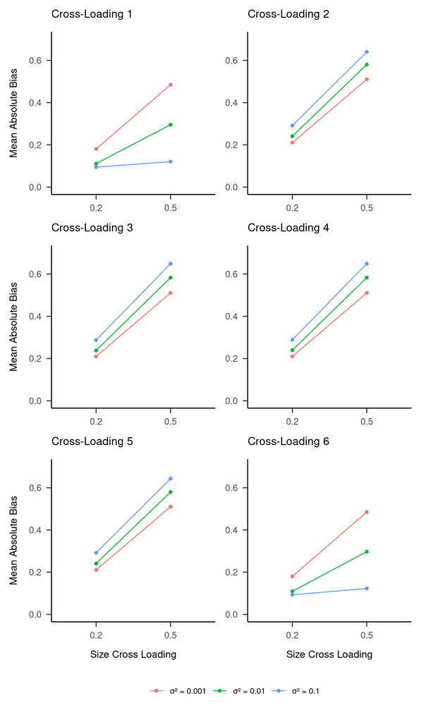

```r
crossLoading1 <-
resultsSVNP %>%
  select(N, biasCrossMean_1, cross, sigmaSqu) %>%
  mutate(label = as.factor(paste0("\u03c3\u00B2 = ", sigmaSqu))) %>%
  group_by(#N,
    cross, label) %>%
  summarise(meanBiasCrossMean_1 = mean(biasCrossMean_1)) %>%
  ggplot(aes(x = as.factor(cross), y = meanBiasCrossMean_1, group = label, col = label))+
  geom_point()+
  geom_line()+
  #facet_wrap(~N)+
  labs(x = NULL,
      y = "Mean Absolute Bias",
      title = "Cross-Loading 1")+
  ylim(0, 0.7)+
  theme_apa()
crossLoading2 <-
resultsSVNP %>%
  select(N, biasCrossMean_2, cross, sigmaSqu) %>%
  mutate(label = as.factor(paste0("\u03c3\u00B2 = ", sigmaSqu))) %>%
  group_by(#N,
    cross, label) %>%
  summarise(meanBiasCrossMean_2 = mean(biasCrossMean_2)) %>%
  ggplot(aes(x = as.factor(cross), y = meanBiasCrossMean_2, group = label, col = label))+
  geom_point()+
  geom_line()+
  #facet_wrap(~N)+
  labs(x = NULL,
       y = NULL,
      # y = "Mean Absolute Bias",
      title = "Cross-Loading 2")+
  ylim(0, 0.7)+
  theme_apa()
crossLoading3 <-
resultsSVNP %>%
  select(N, biasCrossMean_3, cross, sigmaSqu) %>%
  mutate(label = as.factor(paste0("\u03c3\u00B2 = ", sigmaSqu))) %>%
  group_by(#N,
    cross, label) %>%
  summarise(meanBiasCrossMean_3 = mean(biasCrossMean_3)) %>%
  ggplot(aes(x = as.factor(cross), y = meanBiasCrossMean_3, group = label, col = label))+
  geom_point()+
  geom_line()+
  #facet_wrap(~N)+
  labs(x = NULL,
      y = "Mean Absolute Bias",
      title = "Cross-Loading 3")+
  ylim(0, 0.7)+
  theme_apa()
crossLoading4 <-
resultsSVNP %>%
  select(N, biasCrossMean_4, cross, sigmaSqu) %>%
  mutate(label = as.factor(paste0("\u03c3\u00B2 = ", sigmaSqu))) %>%
  group_by(#N,
    cross, label) %>%
  summarise(meanBiasCrossMean_4 = mean(biasCrossMean_4)) %>%
  ggplot(aes(x = as.factor(cross), y = meanBiasCrossMean_4, group = label, col = label))+
  geom_point()+
  geom_line()+
  #facet_wrap(~N)+
  labs(x = NULL,
       y = NULL,
      title = "Cross-Loading 4")+
  ylim(0, 0.7)+
  theme_apa()
crossLoading5 <-
resultsSVNP %>%
  select(N, biasCrossMean_5, cross, sigmaSqu) %>%
  mutate(label = as.factor(paste0("\u03c3\u00B2 = ", sigmaSqu))) %>%
  group_by(#N,
    cross, label) %>%
  summarise(meanBiasCrossMean_5 = mean(biasCrossMean_5)) %>%
  ggplot(aes(x = as.factor(cross), y = meanBiasCrossMean_5, group = label, col = label))+
  geom_point()+
  geom_line()+
  #facet_wrap(~N)+
  labs(x = "Size Cross Loading",
       y = "Mean Absolute Bias",
      title = "Cross-Loading 5")+
  ylim(0, 0.7)+
  theme_apa()
crossLoading6 <-
resultsSVNP %>%
  select(N, biasCrossMean_6, cross, sigmaSqu) %>%
  mutate(label = as.factor(paste0("\u03c3\u00B2 = ", sigmaSqu))) %>%
  group_by(#N,
    cross, label) %>%
  summarise(meanBiasCrossMean_6 = mean(biasCrossMean_6)) %>%
  ggplot(aes(x = as.factor(cross), y = meanBiasCrossMean_6, group = label, col = label))+
  geom_point()+
  geom_line()+
  #facet_wrap(~N)+
  labs(
        x = "Size Cross Loading",
       y = NULL,
      title = "Cross-Loading 6")+
  ylim(0, 0.7)+
  theme_apa()
crossLoadings <- crossLoading1 + crossLoading2  + crossLoading3 + crossLoading4 + crossLoading5 + crossLoading6
crossLoadings + plot_layout(guides = "collect", ncol = 2) & theme(legend.position = "bottom", legend.title = element_blank())
```

```r
png(file = "~/Downloads/crossLoadings.png", width=400, height=600)
crossLoadings + plot_layout(guides = "collect", ncol = 2) & theme(legend.position = "bottom", legend.title = element_blank())
dev.off()
```

```r
resultsSVNP %>%
  select(crossEstMean_1:crossEstMean_6, sigma, cross) %>%
  group_by(sigma, cross) %>%
    summarise_all(mean)
```

```
## # A tibble: 6 × 8
## # Groups:   sigma [3]
##    sigma cross crossEstMean_1 crossEstMean_2 crossEstMean_3 crossEstMean_4
##    <dbl> <dbl>          <dbl>          <dbl>          <dbl>          <dbl>
## 1 0.0316   0.2         0.0195        -0.0104       -0.00985        -0.0102
## 2 0.0316   0.5         0.0153        -0.0103       -0.0106         -0.0106
## 3 0.1      0.2         0.0888        -0.0408       -0.0382         -0.0397
## 4 0.1      0.5         0.204         -0.0802       -0.0828         -0.0831
## 5 0.316    0.2         0.111         -0.0912       -0.0874         -0.0888
## 6 0.316    0.5         0.384         -0.140        -0.149          -0.149
## # … with 2 more variables: crossEstMean_5 <dbl>, crossEstMean_6 <dbl>
```

### Factor Correlation

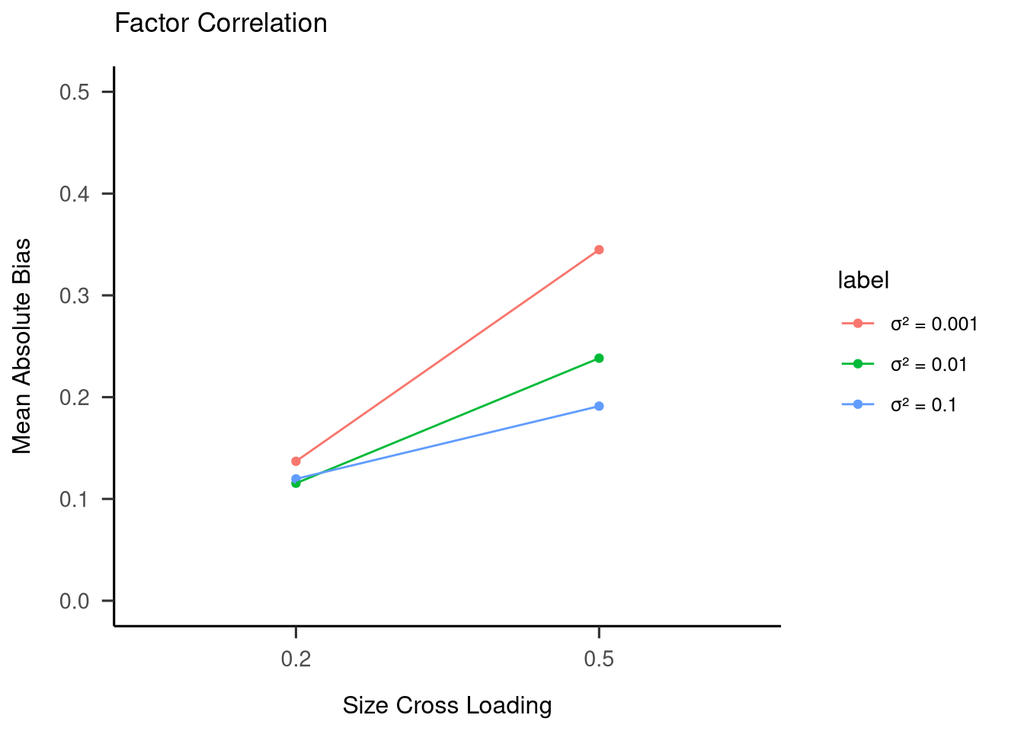

```r
factCorr <-
resultsSVNP %>%
  select(N, biasFactCorrMean, cross, sigmaSqu) %>%
  mutate(label = as.factor(paste0("\u03c3\u00B2 = ", sigmaSqu))) %>%
  group_by(#N,
           cross, label) %>%
  summarise(meanBiasFactCorrMean = mean(biasFactCorrMean)) %>%
  ggplot(aes(x = as.factor(cross), y = meanBiasFactCorrMean, group = label, col = label))+
  geom_point()+
  geom_line()+
  #facet_wrap(~N)+
  labs(x = "Size Cross Loading",
       y = "Mean Absolute Bias",
      title = "Factor Correlation")+
  ylim(0, 0.5)+
  theme_apa()
factCorr
```

```r
png(file = "~/Downloads/factCorr.png", width=300, height=250)
factCorr + plot_layout(guides = "collect", ncol = 2) & theme(legend.position = "bottom", legend.title = element_blank())
dev.off()
```

### Main Loadings

[figure not shown]

```r
mainLoading1 <-
resultsSVNP %>%
  select(N, biasMainMean_1, cross, sigmaSqu) %>%
  mutate(label = as.factor(paste0("\u03c3\u00B2 = ", sigmaSqu))) %>%
  group_by(#N,
           cross, label) %>%
  summarise(meanBiasMainMean_1 = mean(biasMainMean_1)) %>%
  ggplot(aes(x = as.factor(cross), y = meanBiasMainMean_1, group = label, col = label))+
  geom_point()+
  geom_line()+
  #facet_wrap(~N)+
  labs(x = NULL,
       y = "Mean Absolute Bias",
      title = "Main Loading 1")+
  ylim(0, 0.5)+
  theme_apa()
mainLoading2 <-
resultsSVNP %>%
  select(N, biasMainMean_2, cross, sigmaSqu) %>%
  mutate(label = as.factor(paste0("\u03c3\u00B2 = ", sigmaSqu))) %>%
  group_by(#N,
           cross, label) %>%
  summarise(meanBiasMainMean_2 = mean(biasMainMean_2)) %>%
  ggplot(aes(x = as.factor(cross), y = meanBiasMainMean_2, group = label, col = label))+
  geom_point()+
  geom_line()+
  #facet_wrap(~N)+
  labs(x = NULL,
      y = NULL,
      title = " Main Loading 2")+
  ylim(0, 0.5)+
  theme_apa()
mainLoading3 <-
resultsSVNP %>%
  select(N, biasMainMean_3, cross, sigmaSqu) %>%
  mutate(label = as.factor(paste0("\u03c3\u00B2 = ", sigmaSqu))) %>%
  group_by(#N,
           cross, label) %>%
  summarise(meanBiasMainMean_3 = mean(biasMainMean_3)) %>%
  ggplot(aes(x = as.factor(cross), y = meanBiasMainMean_3, group = label, col = label))+
  geom_point()+
  geom_line()+
  #facet_wrap(~N)+
  labs(x = NULL,
      y = "Mean Absolute Bias",
      title = "Main Loading 3")+
  ylim(0, 0.5)+
  theme_apa()
mainLoading4 <-
resultsSVNP %>%
  select(N, biasMainMean_4, cross, sigmaSqu) %>%
  mutate(label = as.factor(paste0("\u03c3\u00B2 = ", sigmaSqu))) %>%
  group_by(#N,
           cross, label) %>%
  summarise(meanBiasMainMean_4 = mean(biasMainMean_4)) %>%
  ggplot(aes(x = as.factor(cross), y = meanBiasMainMean_4, group = label, col = label))+
  geom_point()+
  geom_line()+
  #facet_wrap(~N)+
  labs(x = NULL,
       y = NULL,
      title = "Main Loading 4")+
  ylim(0, 0.5)+
  theme_apa()
mainLoading5 <-
resultsSVNP %>%
  select(N, biasMainMean_5, cross, sigmaSqu) %>%
  mutate(label = as.factor(paste0("\u03c3\u00B2 = ", sigmaSqu))) %>%
  group_by(#N,
           cross, label) %>%
  summarise(meanBiasMainMean_5 = mean(biasMainMean_5)) %>%
  ggplot(aes(x = as.factor(cross), y = meanBiasMainMean_5, group = label, col = label))+
  geom_point()+
  geom_line()+
  #facet_wrap(~N)+
  labs(x = "Size Cross Loading",
       y = "Mean Absolute Bias",
      title = " Main Loading 5")+
    ylim(0, 0.5)+
  theme_apa()
mainLoading6 <-
resultsSVNP %>%
  select(N, biasMainMean_6, cross, sigmaSqu) %>%
  mutate(label = as.factor(paste0("\u03c3\u00B2 = ", sigmaSqu))) %>%
  group_by(#N,
           cross, label) %>%
  summarise(meanBiasMainMean_6 = mean(biasMainMean_6)) %>%
  ggplot(aes(x = as.factor(cross), y = meanBiasMainMean_6, group = label, col = label))+
  geom_point()+
  geom_line()+
  labs(x = "Size Cross Loading",
      y = NULL,
      title = "Main Loading 6")+
  ylim(0, 0.5)+
  theme_apa()
mainLoadings <- mainLoading1+mainLoading2 +  mainLoading3+mainLoading4 + mainLoading5 +mainLoading6

mainLoadings + plot_layout(guides = "collect", ncol = 2) & theme(legend.position = "bottom", legend.title = element_blank())
```

```r
png(file = "~/Downloads/mainLoadings.png", width=400, height=600)
mainLoadings + plot_layout(guides = "collect", ncol = 2) & theme(legend.position = "bottom", legend.title = element_blank())
dev.off()
```

### Residual Variances

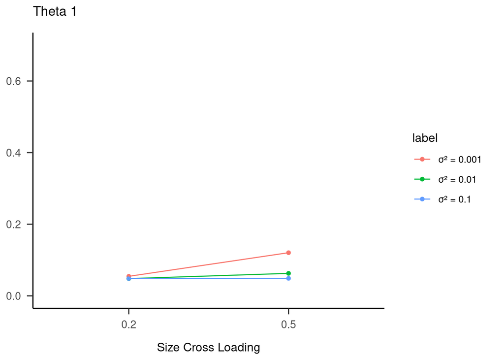

```r
theta1 <-
resultsSVNP %>%
  select(N, biasThetaMean_1, cross, sigmaSqu) %>%
  mutate(label = as.factor(paste0("\u03c3\u00B2 = ", sigmaSqu))) %>%
  group_by(#N,
           cross, label) %>%
  summarise(meanBiastheta1 = mean(biasThetaMean_1)) %>%
  ggplot(aes(x = as.factor(cross), y = meanBiastheta1, group = label, col = label))+
  geom_point()+
  geom_line()+
  labs(x = "Size Cross Loading",
      y = NULL,
      title = "Theta 1")+
  ylim(0, 0.7)+
  theme_apa()
theta1
```

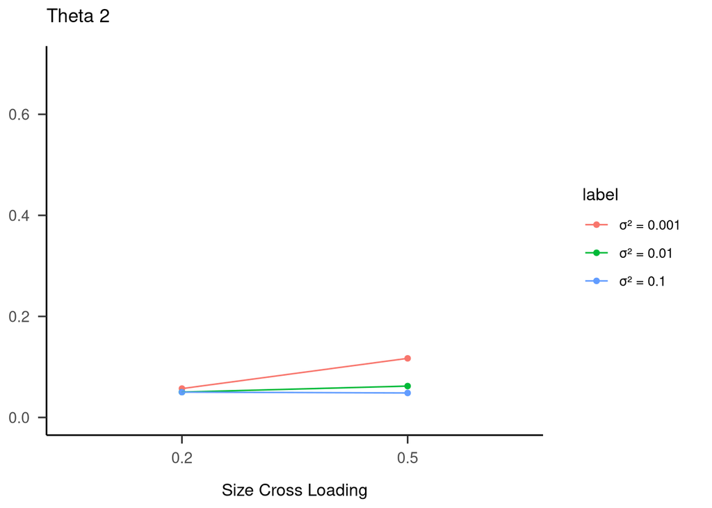

```r
theta2 <-
resultsSVNP %>%
  select(N, biasThetaMean_2, cross, sigmaSqu) %>%
  mutate(label = as.factor(paste0("\u03c3\u00B2 = ", sigmaSqu))) %>%
  group_by(#N,
           cross, label) %>%
  summarise(meanBiastheta2 = mean(biasThetaMean_2)) %>%
  ggplot(aes(x = as.factor(cross), y = meanBiastheta2, group = label, col = label))+
  geom_point()+
  geom_line()+
  labs(x = "Size Cross Loading",
      y = NULL,
      title = "Theta 2")+
  ylim(0, 0.7)+
  theme_apa()
theta2
```

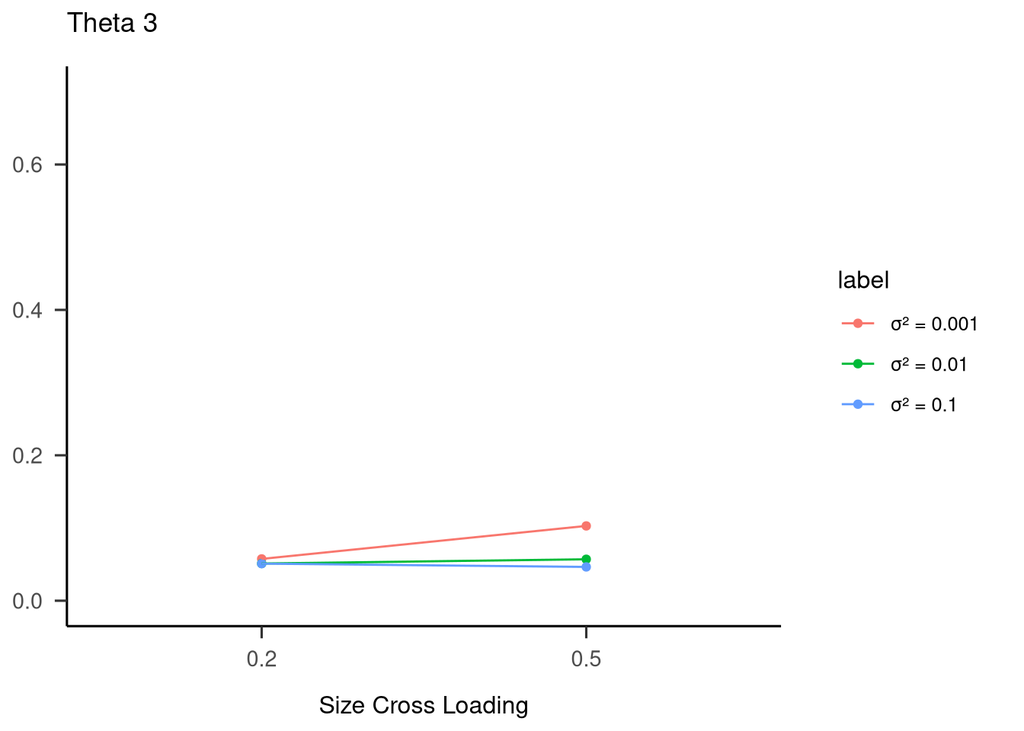

```r
theta3 <-
resultsSVNP %>%
  select(N, biasThetaMean_3, cross, sigmaSqu) %>%
  mutate(label = as.factor(paste0("\u03c3\u00B2 = ", sigmaSqu))) %>%
  group_by(#N,
           cross, label) %>%
  summarise(meanBiastheta3 = mean(biasThetaMean_3)) %>%
  ggplot(aes(x = as.factor(cross), y = meanBiastheta3, group = label, col = label))+
  geom_point()+
  geom_line()+
  labs(x = "Size Cross Loading",
      y = NULL,
      title = "Theta 3")+
  ylim(0, 0.7)+
  theme_apa()
theta3
```

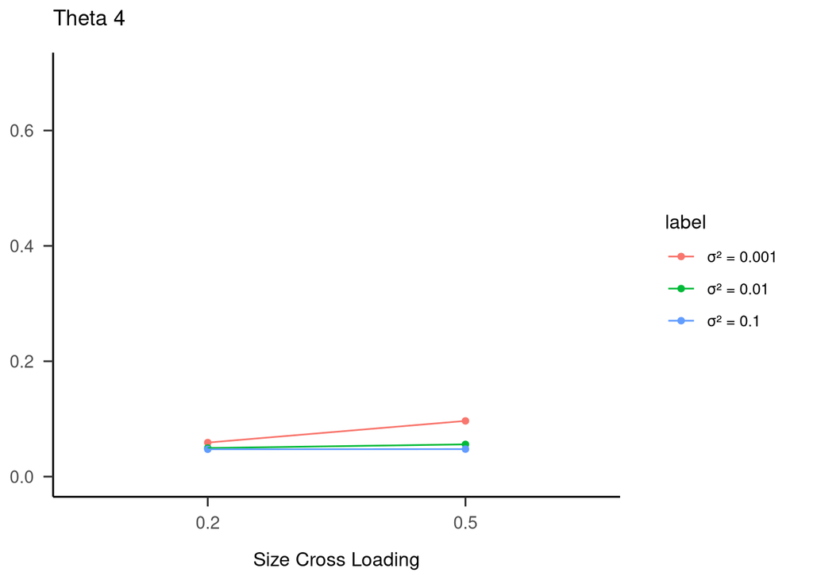

```r
theta4 <-
resultsSVNP %>%
  select(N, biasThetaMean_4, cross, sigmaSqu) %>%
  mutate(label = as.factor(paste0("\u03c3\u00B2 = ", sigmaSqu))) %>%
  group_by(#N,
           cross, label) %>%
  summarise(meanBiastheta4 = mean(biasThetaMean_4)) %>%
  ggplot(aes(x = as.factor(cross), y = meanBiastheta4, group = label, col = label))+
  geom_point()+
  geom_line()+
  labs(x = "Size Cross Loading",
      y = NULL,
      title = "Theta 4")+
  ylim(0, 0.7)+
  theme_apa()
theta4
```

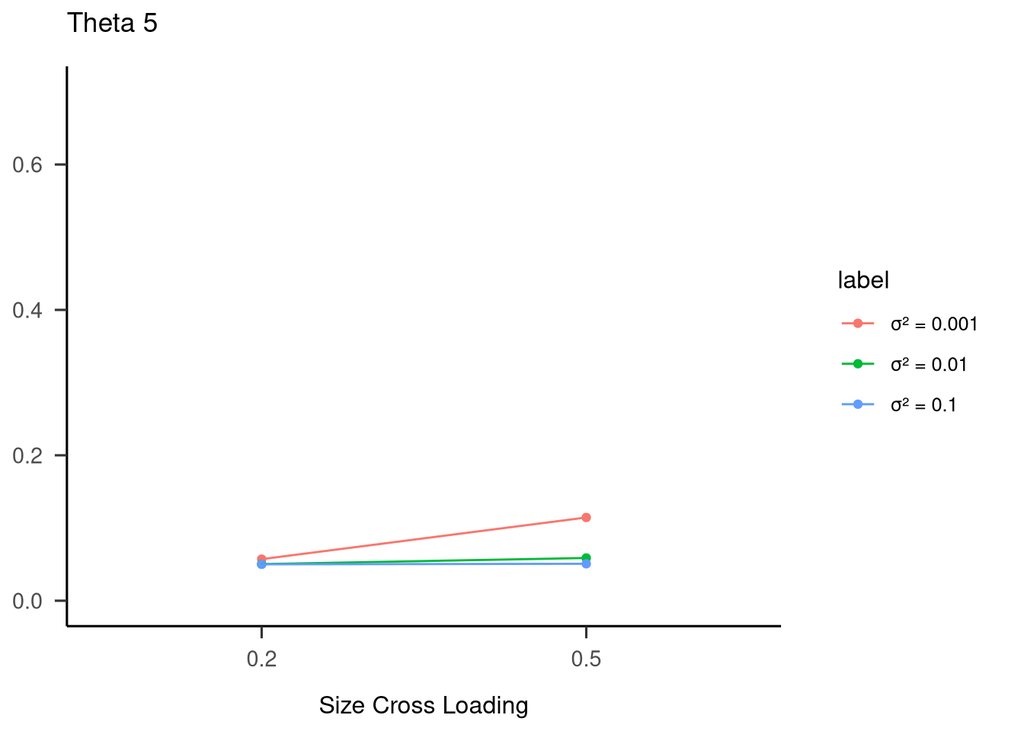

```r
theta5 <-
resultsSVNP %>%
  select(N, biasThetaMean_5, cross, sigmaSqu) %>%
  mutate(label = as.factor(paste0("\u03c3\u00B2 = ", sigmaSqu))) %>%
  group_by(#N,
           cross, label) %>%
  summarise(meanBiastheta5 = mean(biasThetaMean_5)) %>%
  ggplot(aes(x = as.factor(cross), y = meanBiastheta5, group = label, col = label))+
  geom_point()+
  geom_line()+
  labs(x = "Size Cross Loading",
      y = NULL,
      title = "Theta 5")+
  ylim(0, 0.7)+
  theme_apa()
theta5
```

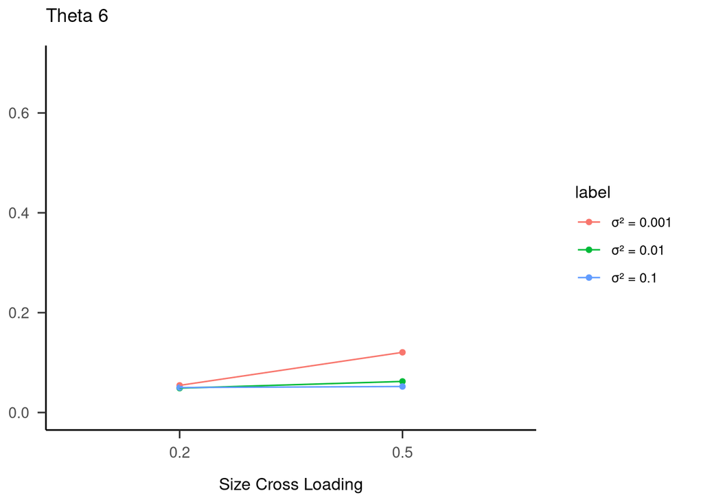

```r
theta6 <-
resultsSVNP %>%
  select(N, biasThetaMean_6, cross, sigmaSqu) %>%
  mutate(label = as.factor(paste0("\u03c3\u00B2 = ", sigmaSqu))) %>%
  group_by(#N,
           cross, label) %>%
  summarise(meanBiastheta6 = mean(biasThetaMean_6)) %>%
  ggplot(aes(x = as.factor(cross), y = meanBiastheta6, group = label, col = label))+
  geom_point()+
  geom_line()+
  labs(x = "Size Cross Loading",
      y = NULL,
      title = "Theta 6")+
  ylim(0, 0.7)+
  theme_apa()
theta6
```

## ALL AT ONCE

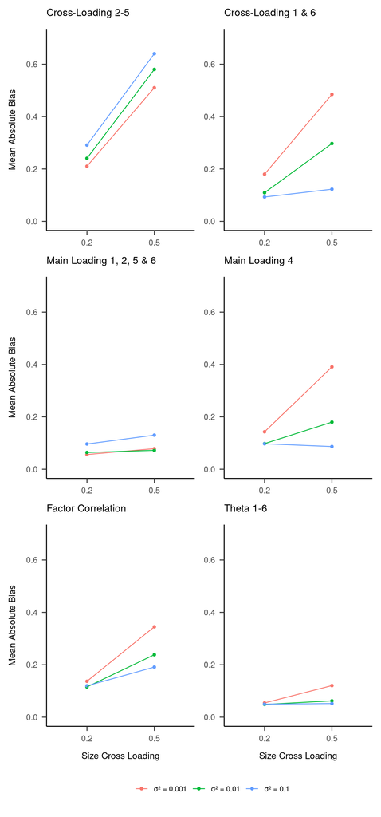

```r
crossLoadingsLowBias <-
resultsSVNP %>%
  select(N, biasCrossMean_2, cross, sigmaSqu) %>%
  mutate(label = as.factor(paste0("\u03c3\u00B2 = ", sigmaSqu))) %>%
  group_by(#N,
    cross, label) %>%
  summarise(meanBiasCrossMean_2 = mean(biasCrossMean_2)) %>%
  ggplot(aes(x = as.factor(cross), y = meanBiasCrossMean_2, group = label, col = label))+
  geom_point()+
  geom_line()+
  #facet_wrap(~N)+
  labs(x = NULL,
       y = "Mean Absolute Bias",
      title = "Cross-Loading 2-5")+
  ylim(0, 0.7)+
  theme_apa()
crossLoadingHighBias <-
resultsSVNP %>%
  select(N, biasCrossMean_6, cross, sigmaSqu) %>%
  mutate(label = as.factor(paste0("\u03c3\u00B2 = ", sigmaSqu))) %>%
  group_by(#N,
    cross, label) %>%
  summarise(meanBiasCrossMean_6 = mean(biasCrossMean_6)) %>%
  ggplot(aes(x = as.factor(cross), y = meanBiasCrossMean_6, group = label, col = label))+
  geom_point()+
  geom_line()+
  #facet_wrap(~N)+
  labs(
        x = NULL,
       y = NULL,
      title = "Cross-Loading 1 & 6")+
  ylim(0, 0.7)+
  theme_apa()
mainLoadingsLowBias <-
resultsSVNP %>%
  select(N, biasMainMean_6, cross, sigmaSqu) %>%
  mutate(label = as.factor(paste0("\u03c3\u00B2 = ", sigmaSqu))) %>%
  group_by(#N,
           cross, label) %>%
  summarise(meanBiasMainMean_6 = mean(biasMainMean_6)) %>%
  ggplot(aes(x = as.factor(cross), y = meanBiasMainMean_6, group = label, col = label))+
  geom_point()+
  geom_line()+
  labs(x = NULL,
      y = "Mean Absolute Bias",
      title = "Main Loading 1, 2, 5 & 6")+
  ylim(0, 0.7)+
  theme_apa()
mainLoadingsHighBias <-
resultsSVNP %>%
  select(N, biasMainMean_4, cross, sigmaSqu) %>%
  mutate(label = as.factor(paste0("\u03c3\u00B2 = ", sigmaSqu))) %>%
  group_by(#N,
           cross, label) %>%
  summarise(meanBiasMainMean_4 = mean(biasMainMean_4)) %>%
  ggplot(aes(x = as.factor(cross), y = meanBiasMainMean_4, group = label, col = label))+
  geom_point()+
  geom_line()+
  #facet_wrap(~N)+
  labs(x = NULL,
       y = NULL,
      title = "Main Loading 4")+
  ylim(0, 0.7)+
  theme_apa()
factCorr <-
resultsSVNP %>%
  select(N, biasFactCorrMean, cross, sigmaSqu) %>%
  mutate(label = as.factor(paste0("\u03c3\u00B2 = ", sigmaSqu))) %>%
  group_by(#N,
           cross, label) %>%
  summarise(meanBiasFactCorrMean = mean(biasFactCorrMean)) %>%
  ggplot(aes(x = as.factor(cross), y = meanBiasFactCorrMean, group = label, col = label))+
  geom_point()+
  geom_line()+
  #facet_wrap(~N)+
  labs(x = "Size Cross Loading",
       y = "Mean Absolute Bias",
      title = "Factor Correlation")+
  ylim(0, 0.7)+
  theme_apa()
thetas <-
resultsSVNP %>%
  select(N, biasThetaMean_6, cross, sigmaSqu) %>%
  mutate(label = as.factor(paste0("\u03c3\u00B2 = ", sigmaSqu))) %>%
  group_by(#N,
           cross, label) %>%
  summarise(meanBiastheta6 = mean(biasThetaMean_6)) %>%
  ggplot(aes(x = as.factor(cross), y = meanBiastheta6, group = label, col = label))+
  geom_point()+
  geom_line()+
  labs(x = "Size Cross Loading",
       y = NULL,
       title = "Theta 1-6")+
  ylim(0, 0.7)+
  theme_apa()
allAtOnce <- crossLoadingsLowBias + crossLoadingHighBias + mainLoadingsLowBias + mainLoadingsHighBias + factCorr + thetas
allAtOnce + plot_layout(guides = "collect", ncol = 2) & theme(legend.position = "bottom", legend.title = element_blank())
```

```r
png(file = "~/1vs2StepBayesianRegSEM/Rmd/figures/allPars.png", width=400, height=700)
allAtOnce + plot_layout(guides = "collect", ncol = 2) & theme(legend.position = "bottom", legend.title = element_blank())
dev.off()
```